# IE0005 mini-project Group 2

## Cardivascular Disease Project

Cardiovascular Dieseases (CVDs) are a group of disorders of the heart and blood vessels and include coronary heart disease, cerebrovascular disease, rheumatic heart disease and other conditions (WHO). CVDs takes approximately 17,9 million lives annually around the globe, making it the leading cause of death globally. In singapore, nearly 1/3 of the deaths are due to heart disease or stroke alone.

This has prompted us to analyse this dataset using various data analysis, data science and machine learning techniques to gain insights regarding the rather prevalent issue. Our project aims to find out which variable is the most important in judging presence of CVDs in a person.

```python
import numpy as np # scientific computing
import pandas as pd # high-performance data structures
import matplotlib.pyplot as plt # data visualization
import seaborn as sb # high-level data visualization
import os

from sklearn import preprocessing
```

```python
# Import data
CardioData = pd.read_csv("cardio_train.csv", sep=';')

# First 5 row of dataset
CardioData.head()
```

|  | id | age | gender | height | weight | ap_hi | ap_lo | cholesterol | gluc | smoke | alco | active | cardio |
| --- | --- | --- | --- | --- | --- | --- | --- | --- | --- | --- | --- | --- | --- |
| 0 | 0 | 18393 | 2 | 168 | 62.0 | 110 | 80 | 1 | 1 | 0 | 0 | 1 | 0 |
| 1 | 1 | 20228 | 1 | 156 | 85.0 | 140 | 90 | 3 | 1 | 0 | 0 | 1 | 1 |
| 2 | 2 | 18857 | 1 | 165 | 64.0 | 130 | 70 | 3 | 1 | 0 | 0 | 0 | 1 |
| 3 | 3 | 17623 | 2 | 169 | 82.0 | 150 | 100 | 1 | 1 | 0 | 0 | 1 | 1 |
| 4 | 4 | 17474 | 1 | 156 | 56.0 | 100 | 60 | 1 | 1 | 0 | 0 | 0 | 0 |

```python
# Basic information about the dataset
CardioData.info()
print("\nData Shape:",CardioData.shape)
print("Data type:",type(CardioData))
```

```
<class 'pandas.core.frame.DataFrame'>
RangeIndex: 70000 entries, 0 to 69999
Data columns (total 13 columns):
 #   Column       Non-Null Count  Dtype
---  ------       --------------  -----
 0   id           70000 non-null  int64
 1   age          70000 non-null  int64
 2   gender       70000 non-null  int64
 3   height       70000 non-null  int64
 4   weight       70000 non-null  float64
 5   ap_hi        70000 non-null  int64
 6   ap_lo        70000 non-null  int64
 7   cholesterol  70000 non-null  int64
 8   gluc         70000 non-null  int64
 9   smoke        70000 non-null  int64
 10  alco         70000 non-null  int64
 11  active       70000 non-null  int64
 12  cardio       70000 non-null  int64
dtypes: float64(1), int64(12)
memory usage: 6.9 MB

Data Shape: (70000, 13)
Data type: <class 'pandas.core.frame.DataFrame'>
```

It can be observed that there are no data type problems.

## Data preprocessing

We begin cleaning data to ensure the dataset is optimal for analysis and eventually, machine learning.

```python
# Create a copy of the dataset
CVdata = CardioData.copy()
```

Base on the dataset, there are 5 numerical variables:

1. age
2. height
3. weight
4. ap_hi
5. ap_lo

and 6 categorical vairables:

1. gender (Male/Female)
2. cholesterol (Cholesterol Levels)
3. gluc (Glucose Levels)
4. smoke (Smoke/Doesn't smoke)
5. alco (Alcohol intake)
6. active (Physically/Physically Inactive)

As pandas.info() takes as attribute as numerical type, we have to convert the "categorical" type to "category" data types.

```python
# Remove id column
CVdata = CVdata.drop(columns='id')

# List for categorical variables
cat_attribs = ['gender', 'cholesterol', 'gluc', 'smoke', 'alco', 'active']

# List for numerical variables
num_attribs = ['age', 'height', 'weight', 'ap_hi', 'ap_lo']

# Convert categorical variables into “category” data type
for cat_attrib in cat_attribs:
    CVdata[cat_attrib] = CVdata[cat_attrib].astype('category') # convert data
CVdata
```

|  | age | gender | height | weight | ap_hi | ap_lo | cholesterol | gluc | smoke | alco | active | cardio |
| --- | --- | --- | --- | --- | --- | --- | --- | --- | --- | --- | --- | --- |
| 0 | 18393 | 2 | 168 | 62.0 | 110 | 80 | 1 | 1 | 0 | 0 | 1 | 0 |
| 1 | 20228 | 1 | 156 | 85.0 | 140 | 90 | 3 | 1 | 0 | 0 | 1 | 1 |
| 2 | 18857 | 1 | 165 | 64.0 | 130 | 70 | 3 | 1 | 0 | 0 | 0 | 1 |
| 3 | 17623 | 2 | 169 | 82.0 | 150 | 100 | 1 | 1 | 0 | 0 | 1 | 1 |
| 4 | 17474 | 1 | 156 | 56.0 | 100 | 60 | 1 | 1 | 0 | 0 | 0 | 0 |
| ... | ... | ... | ... | ... | ... | ... | ... | ... | ... | ... | ... | ... |
| 69995 | 19240 | 2 | 168 | 76.0 | 120 | 80 | 1 | 1 | 1 | 0 | 1 | 0 |
| 69996 | 22601 | 1 | 158 | 126.0 | 140 | 90 | 2 | 2 | 0 | 0 | 1 | 1 |
| 69997 | 19066 | 2 | 183 | 105.0 | 180 | 90 | 3 | 1 | 0 | 1 | 0 | 1 |
| 69998 | 22431 | 1 | 163 | 72.0 | 135 | 80 | 1 | 2 | 0 | 0 | 0 | 1 |
| 69999 | 20540 | 1 | 170 | 72.0 | 120 | 80 | 2 | 1 | 0 | 0 | 1 | 0 |

70000 rows × 12 columns

## Numerical Data Analysis

Now we will visualise the data to make better sense of how our data is looking like. We will use box plots for prelimary data representation.

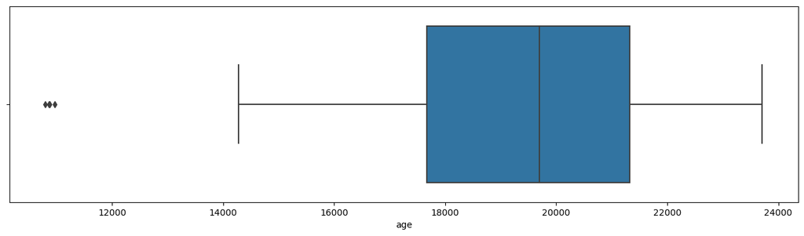

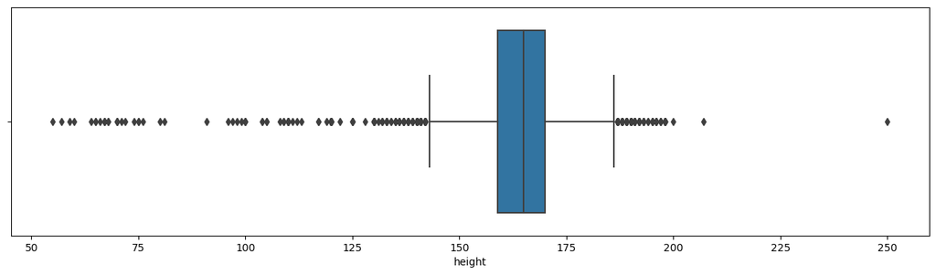

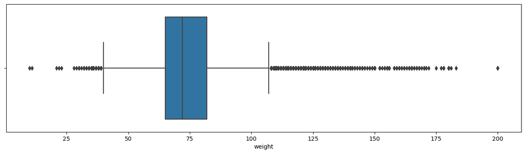

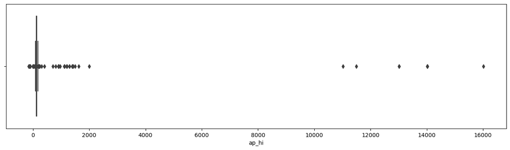

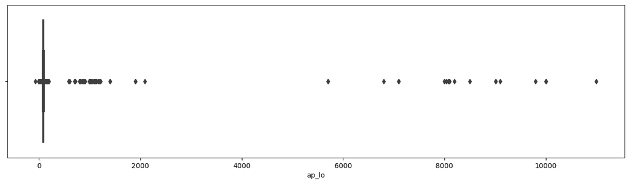

```python
# Extract numerical attributes from the dataset
numeric_data = pd.DataFrame(CVdata[num_attribs])

# Boxplot of the numeric data
for var in numeric_data: # iterate over
    fig, axes = plt.subplots(nrows=1, ncols=1, figsize=(16,4)) # setup the fr
    sb.boxplot(data=CVdata, x=var, orient='h') # box plot
```

```python
# Summary of numerical attributes' statistics
CVdata.describe().transpose()
```

|  | count | mean | std | min | 25% | 50% | 75% | max |
| --- | --- | --- | --- | --- | --- | --- | --- | --- |
| age | 70000.0 | 19468.865814 | 2467.251667 | 10798.0 | 17664.0 | 19703.0 | 21327.0 | 23713.0 |
| height | 70000.0 | 164.359229 | 8.210126 | 55.0 | 159.0 | 165.0 | 170.0 | 250.0 |
| weight | 70000.0 | 74.205690 | 14.395757 | 10.0 | 65.0 | 72.0 | 82.0 | 200.0 |
| ap_hi | 70000.0 | 128.817286 | 154.011419 | -150.0 | 120.0 | 120.0 | 140.0 | 16020.0 |
| ap_lo | 70000.0 | 96.630414 | 188.472530 | -70.0 | 80.0 | 80.0 | 90.0 | 11000.0 |
| cardio | 70000.0 | 0.499700 | 0.500003 | 0.0 | 0.0 | 0.0 | 1.0 | 1.0 |

## Data quality observation

As per the description of the numerical data, we identified that both min value for both ap_hi and ap-low, -150.0 and -70.0 respectively, are negative. This is unrealistic and indicate the presence of possible outliers.

The age is also represented in terms of number of days, we will be changing it to represent the number of years of age. This is more intuitive and easier to understand.

The height and weight also has unrealistic minimum and maximum, hence had to be filtered.

```python
# Convert the age into years
CVdata['age'] = CVdata['age'] // 365.25
```

## Cleaning and feature engineering

**BMI**

Since the max and min for the height and weight is unrealistic given the min age of 29, the 2 variables have to be cleaned for us to continue to calculate the BMI for further analysis

To clean the weight and height data, we can remove weights and heights, that fall below 2.5% or above 97.5% of a given range. This will give us a more realistic parameter

```python
# filter unrealistic weight and height data
CVdata.drop(CVdata[(CVdata['height'] > CVdata['height'].quantile(0.975)) |
                   (CVdata['height'] < CVdata['height'].quantile(0.025))].index,inplace=True)
CVdata.drop(CVdata[(CVdata['weight'] > CVdata['weight'].quantile(0.975)) |
                   (CVdata['weight'] < CVdata['weight'].quantile(0.025))].index,inplace=True)
```

To make better use of the height and weight data, We calculate the BMI of each sample by following **BMI = Weight(kg)/Height^2(m)** and add a new column into the data.

```python
CVdata_v1 = CVdata.copy()

CVdata_v1['BMI'] = CVdata['weight']/((CVdata['height']/100)**2)
BMI = pd.DataFrame(CVdata_v1[['BMI']])
BMI.describe()
```

|  | BMI |
| --- | --- |
| count | 63866.000000 |
| mean | 27.232986 |
| std | 4.446555 |
| min | 16.049383 |
| 25% | 23.875433 |
| 50% | 26.298488 |
| 75% | 29.823253 |
| max | 46.666667 |

**Blood Pressure**

Based on the boxplot for ap_hi and ap_lo, there are a lot of outliers that can be filtered out. Systolic(bp after heart contracts) and diastolic(bp before heart contracts) blood pressure should be within 33 - 180 mmHg in non-emergency cases as seen in the table below(excluding "dangerously low" and "hypertensive crisis").

In this prelimary data preparation, we want to find out how many outliers do we have amongst our current dataset which we will filter out by limiting the systolic blood pressure (50<=ap_hi<=180) and diastolic blood pressure (34<=ap_lo<=120).

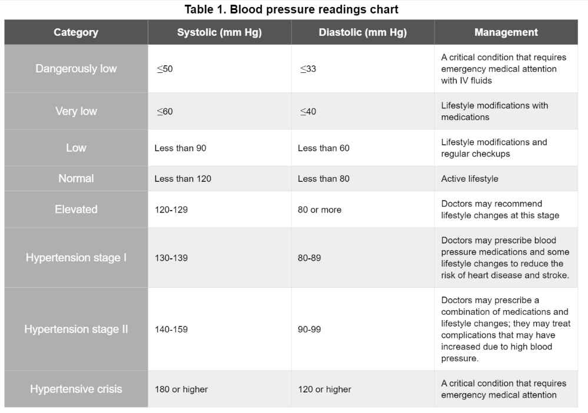